# Practical Machine Learning Project.Rmd

Evan Drake

4/11/2020

## Prediction using Cross Validation

Using the workout dataset I will train a series of tree and random forest models. Each training run will use a different number of k folds to determine the optimal number for prediction.

## Data

The workout data is organized into a training and test set. To train the model I will split the training data set further into a training and testing set and leave the original test set aside for validation.

## Feature Selection

I based on the description of the data 96 features were created during the study to summarize the sensor data. The study authors split the data into various window sizes, from 0.5 seconds up to 2 seconds, then summarized. These summary statistics are only reported on rows of data with the tag “new window”. Given that the predictions must be made on a small set of validation data that does include of any of these statistics I will drop them from my data and make predictions using only the raw input from the sensors.

```r
testing <- readRDS("testing.RDS")
names(testing)
```

```
##  [1] "user_name"            "roll_belt"            "pitch_belt"
##  [4] "yaw_belt"             "total_accel_belt"     "gyros_belt_x"
##  [7] "gyros_belt_y"         "gyros_belt_z"         "accel_belt_x"
## [10] "accel_belt_y"         "accel_belt_z"         "magnet_belt_x"
## [13] "magnet_belt_y"        "magnet_belt_z"        "roll_arm"
## [16] "pitch_arm"            "yaw_arm"              "total_accel_arm"
## [19] "gyros_arm_x"          "gyros_arm_y"          "gyros_arm_z"
## [22] "accel_arm_x"          "accel_arm_y"          "accel_arm_z"
## [25] "magnet_arm_x"         "magnet_arm_y"         "magnet_arm_z"
## [28] "roll_dumbbell"        "pitch_dumbbell"       "yaw_dumbbell"
## [31] "total_accel_dumbbell" "gyros_dumbbell_x"     "gyros_dumbbell_y"
## [34] "gyros_dumbbell_z"     "accel_dumbbell_x"     "accel_dumbbell_y"
## [37] "accel_dumbbell_z"     "magnet_dumbbell_x"    "magnet_dumbbell_y"
## [40] "magnet_dumbbell_z"    "roll_forearm"         "pitch_forearm"
## [43] "yaw_forearm"          "total_accel_forearm"  "gyros_forearm_x"
## [46] "gyros_forearm_y"      "gyros_forearm_z"      "accel_forearm_x"
## [49] "accel_forearm_y"      "accel_forearm_z"      "magnet_forearm_x"
## [52] "magnet_forearm_y"     "magnet_forearm_z"     "classe"
```

## Creating the testing and training data sets

To train the model I will subset the training data set further into a training and testing data set

## Model training runs

I will run two sets of models, tree, and random forest. For validation I will also use zero, 2, 5, and 10 k folds for cross validation.

## Calcuate accuracy of model runs

Model accuracy calculated using the percent of observations that are properly predicted in the testing data set.

```r
modFit_tree_none <- readRDS("modFit_tree_none.RDS")
modFit_tree_cv2 <- readRDS("modFit_tree_cv2.RDS")
modFit_tree_cv5 <- readRDS("modFit_tree_cv5.RDS")
modFit_tree_cv10 <- readRDS("modFit_tree_cv10.RDS")
modFit_rf_none <- readRDS("modFit_rf_none.RDS")
modFit_rf_cv2 <- readRDS("modFit_rf_cv2.RDS")
modFit_rf_cv5 <- readRDS("modFit_rf_cv5.RDS")
modFit_rf_cv10 <- readRDS("modFit_rf_cv10.RDS")

## Test model accuracy and predict

# predict with tree models
pred_tree_none <- predict(modFit_tree_none, testing)
pred_tree_cv2 <- predict(modFit_tree_cv2, testing)
pred_tree_cv5 <- predict(modFit_tree_cv5, testing)
pred_tree_cv10 <- predict(modFit_tree_cv10, testing)

# predict with random forest models
pred_rf_none <- predict(modFit_rf_none, testing)
pred_rf_cv2 <- predict(modFit_rf_cv2, testing)
pred_rf_cv5 <- predict(modFit_rf_cv5, testing)
pred_rf_cv10 <- predict(modFit_rf_cv10, testing)

# cacluate prediction accuracy on testing data set
accuracy_tree_none <- sum(pred_tree_none == testing$classe) / nrow(testing)
accuracy_tree_cv2 <- sum(pred_tree_cv2 == testing$classe) / nrow(testing)
accuracy_tree_cv5 <- sum(pred_tree_cv5 == testing$classe) / nrow(testing)
accuracy_tree_cv10 <- sum(pred_tree_cv10 == testing$classe) / nrow(testing)

accuracy_rf_none <- sum(pred_rf_none == testing$classe) / nrow(testing)
accuracy_rf_cv2 <- sum(pred_rf_cv2 == testing$classe) / nrow(testing)
accuracy_rf_cv5 <- sum(pred_rf_cv5 == testing$classe) / nrow(testing)
accuracy_rf_cv10 <- sum(pred_rf_cv10 == testing$classe) / nrow(testing)

accuracy_nums <- c(accuracy_tree_none, accuracy_tree_cv2, accuracy_tree_cv5, accuracy_tree_cv10,
                   accuracy_rf_none, accuracy_rf_cv2, accuracy_rf_cv5, accuracy_rf_cv10)

run_names <- c("tree_none", "tree_cv2", "tree_cv5", "tree_cv10", "rf_none", "rf_cv2", "rf_cv5", "rf_cv10")

accuracy <- as.data.frame(cbind(run_names, accuracy_nums))
accuracy$model <- c("tree", "tree", "tree", "tree", "rf", "rf", "rf", "rf")
names(accuracy) <- c("run", "accuracy", "model")
accuracy$accuracy <- as.numeric(as.character(accuracy$accuracy))


accuracy
```

```
##         run  accuracy model
## 1 tree_none 0.2844617  tree
## 2  tree_cv2 0.4928630  tree
## 3  tree_cv5 0.4928630  tree
## 4 tree_cv10 0.4928630  tree
## 5   rf_none 0.9938825    rf
## 6    rf_cv2 0.9926591    rf
## 7    rf_cv5 0.9934747    rf
## 8   rf_cv10 0.9930669    rf
```

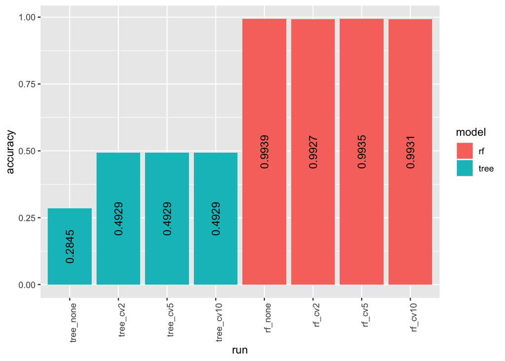

```r
g <- ggplot(data=accuracy, aes(x=run, y=accuracy, fill=model)) + geom_bar(stat="identity") + geom_text(aes(label=round(accuracy,4)), angle = 90, position = position_stack(vjust = 0.5))
g + theme(axis.text.x = element_text(angle = 90, hjust = 1)) + scale_x_discrete(limits=c(run_names))
```

## Model Selection

Given the previous results, I will select the random forest model with 5 k folds. The results from predicting on the validation data set are below

```r
# Final Prediction Using Validation Data Set

validation <- readRDS("validation.RDS")
training <- readRDS("training.RDS")

# select relevant columns of the validation data set
final_cols <- names(training)
strMatch <- final_cols
strMatch <- paste0("^", strMatch, "$", collapse="|")
final_cols_index <- grep(strMatch, names(validation))
validation_final <- validation[,final_cols_index]

# perform prediction on the validation data set
pred_final <- predict(modFit_rf_cv5, validation_final)

pred_final
```

```
##  [1] B A B A A E D B A A B C B A E E A B B B
## Levels: A B C D E
```